# Probability Distributions: Normal

Copyright 2018. William G. Foote. All rights reserved.

# 1 What is normal?

Let’s draw $X_i$ from $1$ to $n$ successes independently from a population where $\mu$ and $\sigma$ are known, then we would discover that the standardized average

$$\frac{\bar{x} - \mu}{\sigma / \sqrt{n}}$$

is asymptotically normal with mean 0 and variance 1 (often called normal(0,1)). * This can be interpreted as when $n$ is large enough the average is approximately normal with mean $\mu$ and standard deviation $\sigma / \sqrt{n}$.

- This result is also known as the *Central Limit Theorem* (CLT), a cornerstone of classical statistics.
- Normal means a symmetric distribution with *mesokurtic* “tailedness”, or kurtosis of 3. This implies there are not too many rare outcomes in the tails of the distribution.

# 2 How can we check this?

Simulation is an excellent way. Now to get your feet good and wet…

Let’s first do this for the binomial distribution, the CLT translates into saying that if $x_n$ are binomial distribution outcomes with parameters $n$ and $p$ then

$$z = \frac{x_n - np}{\sqrt{np(1-p)}}$$

then the standardized $x$, called $z$, is approximately `Normal(0,1)`.

# 3 Let’s investigate

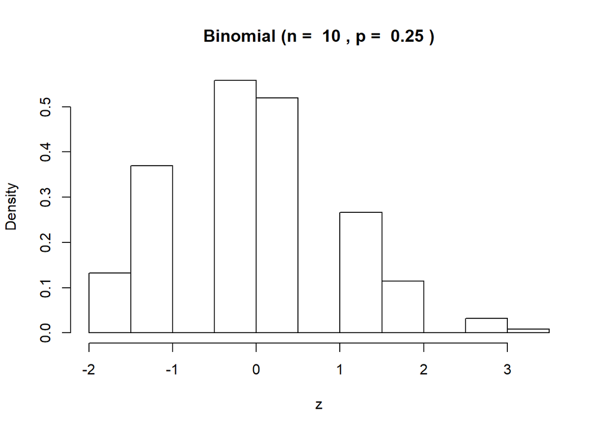

Almost bell-shaped. A little lop-sided too… Here are some statistics on our experimental runs.

| mean | std_dev | median | skewness | kurtosis |
| --- | --- | --- | --- | --- |
| -0.027 | 0.9983 | -0.3651 | 0.3635 | 3.0047 |

Almost a “normal” *mesokurtotic* result of 3.0. A small skewness indicating a little asymmetry.

Now try this

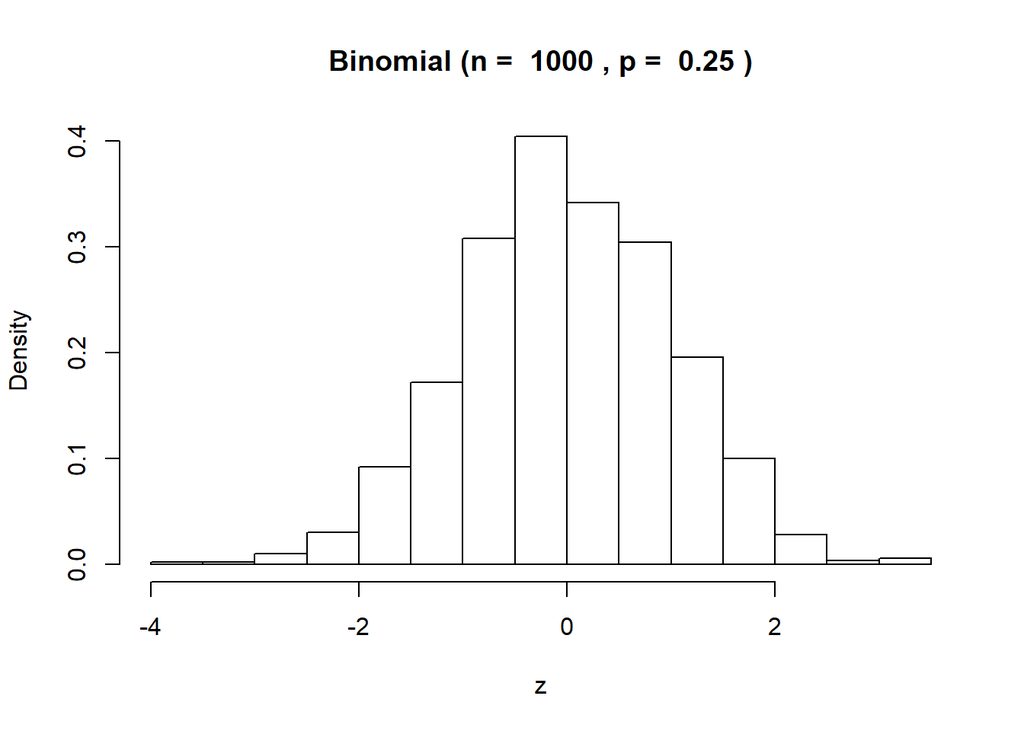

Much more symmetric. Here are some summary statistics.

| mean | std_dev | median | skewness | kurtosis |
| --- | --- | --- | --- | --- |
| 0.0096 | 1.0005 | 0 | -0.0524 | 3.1849 |

- Slightly negatively skewed tail we can eyeball, but very small.
- Mean is near zero, and median not far from zero too.
- Standard deviation is nearly 1.
- Kurtosis is almost on that magic normal mesokurtic number of 3.0.

## 3.1 Let’s look at this

Here is a standard normal distribution, $\mu = 0$, and $\sigma = 1$. This is a distribution centered on 0. How is this like the calculated $z$-score?

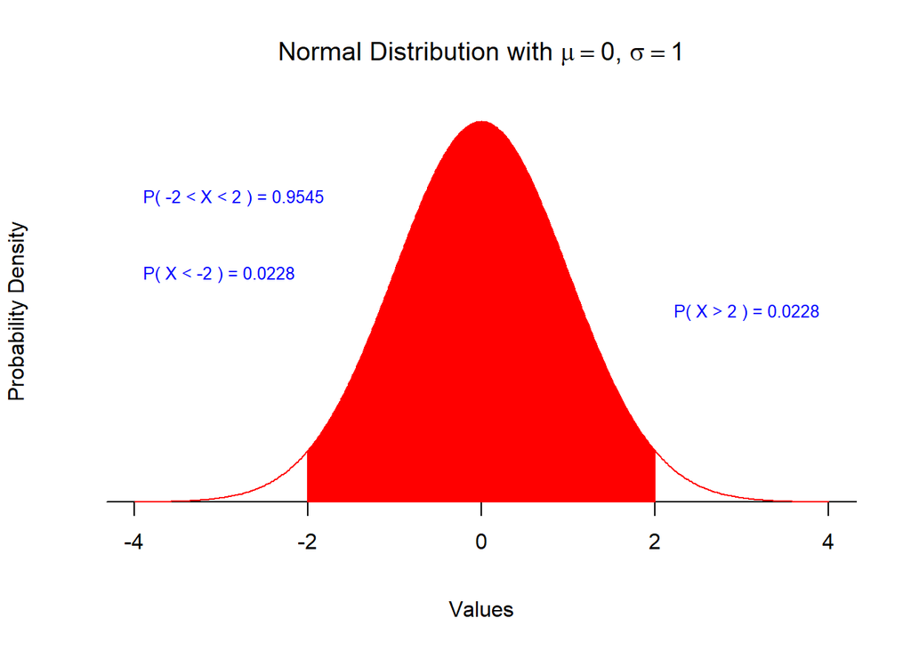

```r
gnorm(0, 1, a = -2, b = 2, calcProb = TRUE)
```

What is the interpretation of the $-2$ and $+2$

What is probability that an outcome is not 2 standard deviations from the mean?

## 3.2 Where do normal outcomes come from?

Is anything normal? Normal distributions very naturally come from a very interesting source: sums and averages of random samples of any set of outcomes.

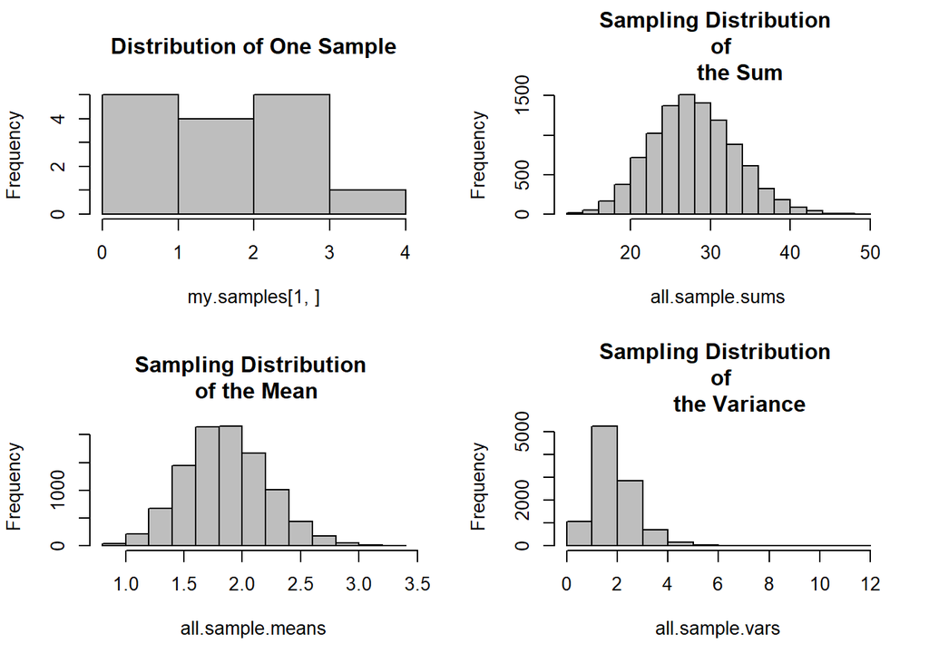

```r
clt_sim(15, source = "P", param1 = 1.89)
```

What do we notice?